# Items selection

Piotr Król

29 06 2021

Content:

- Items used in simulations
  - SE 0.173 stop criterion
  - SE 0.173 + 50 max items stop criterion
- Models with restricted set of items (146)
  - mirt 61 quadratures
  - mirt 101 quadratures
  - mirt 61 quadratures no easy items (146 - 2)
  - mirt 101 quadratures no easy items
  - mirt 151 quadratures no easy items
  - ltm 101 quadratures no easy items
  - ltm 101 quadratures + 472 iterations no easy items
  - TAM default
  - TAM 101 snodes
- CTT difficulty and discrimination

```r
library(mirt)
library(mirtCAT)
library(parallel) #Speeds up simulations (many in parallel)
library(plyr) #For laply
library(ggpubr) #For making plots
library(ltm)
library(TAM)
```

Load already prepared responses & cdi content:

```r
responses_demo <- read.csv("Data/responses_demo.csv", encoding = "UTF-8")
responses <- as.matrix(responses_demo[,5:ncol(responses_demo)])
cdi <- read.csv("Data/cdi.csv", encoding = "UTF-8")
```

# Items used in simulations

Load best *mirt* model with 601 quadratures (the highest log-likelihood ever obtained):

```r
load("Data/mirt_model_601q")
mirt_model
```

```
##
## Call:
## mirt(data = responses, model = 1, SE = TRUE, quadpts = 601, technical = list(NCYCLES = 10000))
##
## Full-information item factor analysis with 1 factor(s).
## Converged within 1e-04 tolerance after 2652 EM iterations.
## mirt version: 1.33.2
## M-step optimizer: BFGS
## EM acceleration: Ramsay
## Number of rectangular quadrature: 601
## Latent density type: Gaussian
##
## Information matrix estimated with method: Oakes
## Second-order test: model is a possible local maximum
## Condition number of information matrix =  2310.672
##
## Log-likelihood = -462860.7
## Estimated parameters: 1340
## AIC = 928401.3; AICc = 932160.6
## BIC = 936092.1; SABIC = 931834.6
## G2 (9999998660) = 890631.4, p = 1
## RMSEA = 0, CFI = NaN, TLI = NaN
```

```r
mirt_params <- as.data.frame(coef(mirt_model, simplify = TRUE)$items)[1:2]
head(mirt_params)
```

```
##             a1        d
## item1 1.231205 0.405889
## item2 1.356512 2.890774
## item3 1.231575 2.127741
## item4 1.529606 1.496128
## item5 1.396225 2.774855
## item6 1.302376 1.642392
```

## SE 0.173 stop criterion

Simulate CAT with just SE stop criterion:

```r
mo <- generate.mirt_object(mirt_params, '2PL')
design <- list(min_SEM = 0.173) #0.173 corresponds to reliability of 0.97 (which is Polish CDI:WS words reliability)
cl <- makeCluster(detectCores()) #Speeds up simulations (many in paralell)
sim_results <- mirtCAT(mo = mo, method = "MAP", criteria = "MI", start_item = "MI", local_pattern = responses, cl = cl, design = design)
```

Investigate tests lengths needed to achieve stop criterion (SE<=0.173):

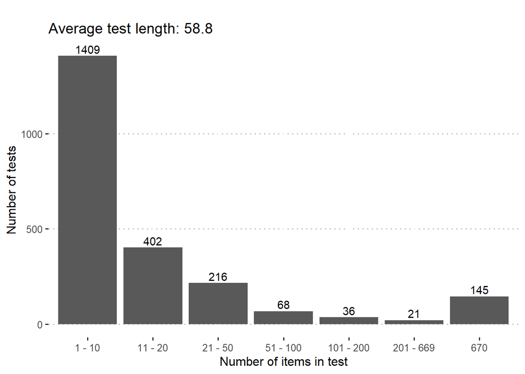

```r
#Obtain lengths
tests_lengths <- laply(sim_results, function(x) length(x$items_answered))

#Prepare cuts
cuts <- cut(tests_lengths, breaks = c(0, 10, 20, 50, 100, 200, 669, 670), labels = c("1 - 10", "11 - 20", "21 - 50", "51 - 100", "101 - 200", "201 - 669", "670"), dig.lab = 0)
df_freq <- as.data.frame(table(cuts))

#Plot distribution
ggplot(df_freq, aes(x = cuts, y = Freq)) +
  xlab("Number of items in test") +
  ylab("Number of tests") +
  geom_bar(stat = "identity") +
  ggtitle(paste0("\nAverage test length: ", round(mean(tests_lengths), 2))) +
  geom_text(aes(label = Freq), vjust = -0.3) +
  theme_pubclean()
```

Calculate frequency of occurence of particular items:

```r
#Prepare df with frequencies of usage of items
frequency_df <- data.frame(number.ws = c(1:nrow(mirt_params)), freq = rep(0, nrow(mirt_params)))

#Update df with number of occurence of given item
for (p in 1:length(sim_results)){
  items <- sim_results[[p]]$items_answered
  for (number.ws in items){
    frequency_df[frequency_df["number.ws"] == number.ws, "freq"] <- frequency_df[frequency_df["number.ws"] == number.ws, "freq"] + 1
  }
}
head(frequency_df)
```

```
##   number.ws freq
## 1         1  219
## 2         2  205
## 3         3  207
## 4         4  225
## 5         5  213
## 6         6  215
```

Add cdi info about items

```r
items_usage <- merge(frequency_df, cdi, by="number.ws")
row.names(items_usage) <- NULL
head(items_usage)
```

```
##   number.ws freq    category number.wg position
## 1         1  219 Z01.odgłosy         1    gę.gę
## 2         2  205 Z01.odgłosy         2  hau.hau
## 3         3  207 Z01.odgłosy         3 ko.ko.ko
## 4         4  225 Z01.odgłosy         4  kwa.kwa
## 5         5  213 Z01.odgłosy         5     miau
## 6         6  215 Z01.odgłosy         6  mee.bee
```

Calculate frequency in percents and order by it

```r
items_usage$freq <- items_usage$freq / length(sim_results)
items_usage <- items_usage[order(items_usage$freq, decreasing = T), ]
head(items_usage)
```

```
##     number.ws      freq         category number.wg position
## 457       457 1.0000000   Z16.czasowniki       301    kupić
## 183       183 0.5424467 Z07.części_ciała       122    głowa
## 539       539 0.5363518   Z16.czasowniki        NA  znaleźć
## 188       188 0.3844145 Z07.części_ciała       125     noga
## 521       521 0.3744014   Z16.czasowniki        NA   wiązać
## 189       189 0.3138877 Z07.części_ciała       126      nos
```

Investigate frequency intervals:

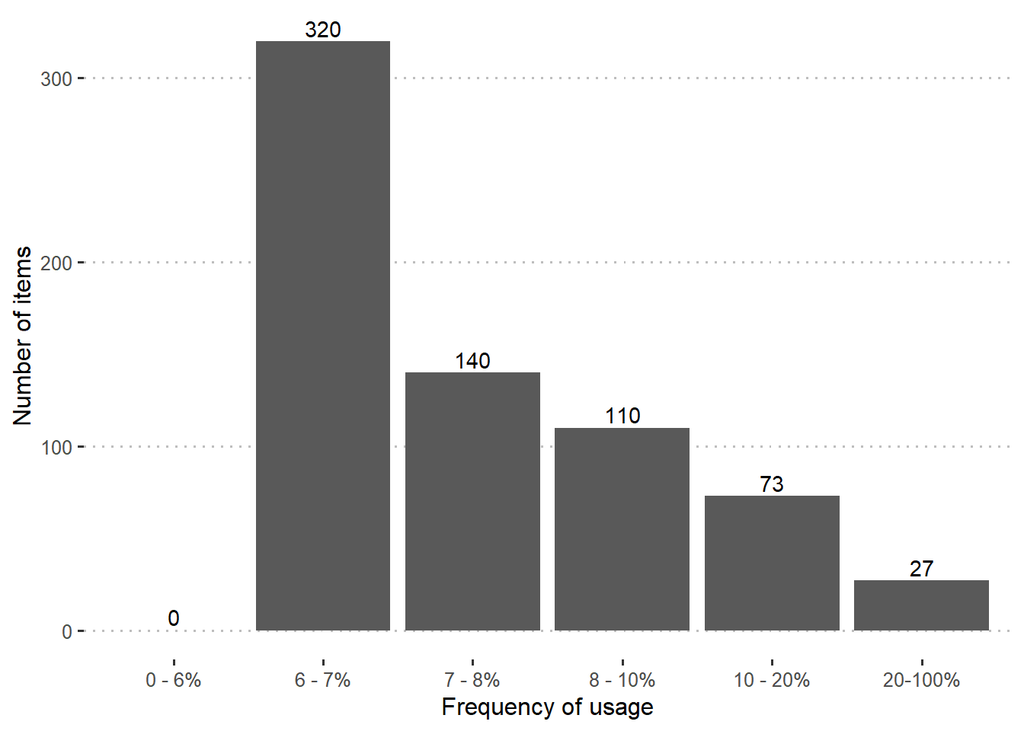

```r
#Prepare cuts
cuts <- cut(items_usage$freq, breaks = c(0, 0.06, 0.07, 0.08, 0.1, 0.2,  1), labels = c("0 - 6%", "6 - 7%", "7 - 8%", "8 - 10%", "10 - 20%", "20-100%"), dig.lab = 0)
df_freq <- as.data.frame(table(cuts))

#Plot distribution
ggplot(df_freq, aes(x = cuts, y = Freq)) +
  xlab("Frequency of usage") +
  ylab("Number of items") +
  geom_bar(stat = "identity") +
  geom_text(aes(label = Freq), vjust = -0.3) +
  theme_pubclean()
```

Select top 100 items and check their category belonging:

```r
best_items <- items_usage[1:100, ]
table(best_items$category)
```

```
##
##                    Z01.odgłosy                  Z02.zwierzęta
##                              0                              5
##                    Z03.pojazdy                    Z04.pokarmy
##                              3                              5
##                    Z05.zabawki                    Z06.ubrania
##                              4                              2
##               Z07.części_ciała                     Z08.w_domu
##                              9                              3
## Z09.przedmioty_domowego_użytku                  Z10.na_dworze
##                              1                              2
##  Z11.miejsca_gdzie_można_pójść                      Z12.osoby
##                              3                              6
##                    Z13.formuły               Z14.przymiotniki
##                              5                              0
##                 Z15.przysłówki                 Z16.czasowniki
##                              0                             14
##         Z17.określenia_miejsca           Z18.określenia_czasu
##                              7                              4
##           Z19.określenia_miary             Z20.zaimki_osobowe
##                              4                             10
##          Z21.zaimki_wskazujące                    Z22.pytania
##                              3                              1
##         Z23.przysłówki_modalne                   Z24.przyimki
##                              6                              0
##                   Z25.spójniki
##                              3
```

So there are generally different categories. Let’s check what are the parameters (IRT parametrization) of top 100 items:

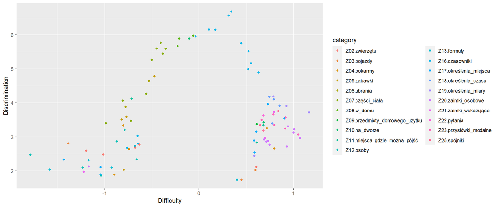

```r
#Prepare df with only best items with IRT params
best_items_ids <- paste0("item", best_items$number.ws)
mirt_params_IRT <- as.data.frame(coef(mirt_model, simplify = TRUE, IRTpars = TRUE)$items)[1:2]
mirt_params_IRT_best <- mirt_params_IRT[best_items_ids, ]
mirt_params_IRT_best <- cbind(mirt_params_IRT_best, best_items)

#Create plot
ggplot(mirt_params_IRT_best, aes(b, a, colour = category)) +
  geom_point() +
  xlab("Difficulty") +
  ylab("Discrimination")
```

See what are parameters of the best items w.r.t parameters of all items:

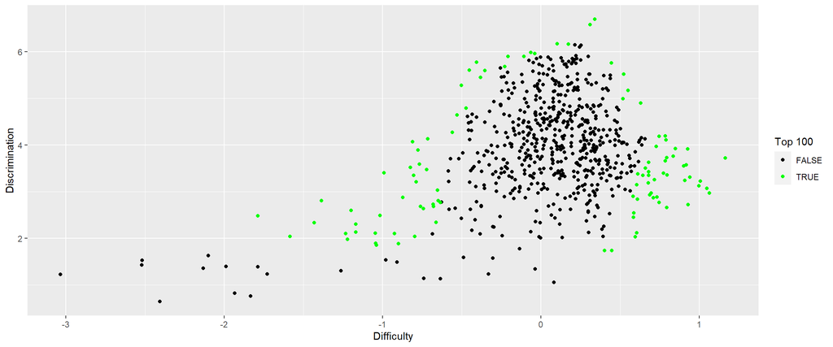

```r
#Prepare df with all params
mirt_params_IRT <- cbind(mirt_params_IRT, cdi)
mirt_params_IRT$top100 <- FALSE
mirt_params_IRT[best_items_ids, "top100"] <- TRUE

#Create plot
ggplot(mirt_params_IRT, aes(b, a, colour = top100)) +
  geom_point() +
  xlab("Difficulty") +
  ylab("Discrimination") +
  labs(colour = "Top 100") +
  scale_color_manual(values = c("Black", "Green"))
```

## SE 0.173 + 50 max items stop criterion

```r
mo <- generate.mirt_object(mirt_params, '2PL')
```

```r
design <- list(min_SEM = 0.173, max_items = 50)
cl <- makeCluster(detectCores())
sim_results <- mirtCAT(mo = mo, method = "MAP", criteria = "MI", start_item = "MI", local_pattern = responses, cl = cl, design = design)
```

Investigate tests lengths needed to achieve stop criterion (SE<=0.173 + max 50 items):

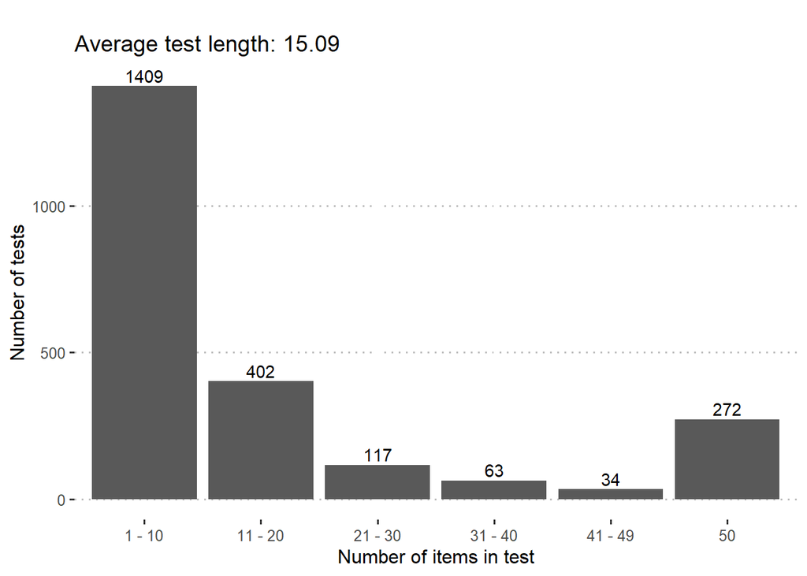

```r
#Obtain lengths
tests_lengths <- laply(sim_results, function(x) length(x$items_answered))

#Prepare cuts
cuts <- cut(tests_lengths, breaks = c(0, 10, 20, 30, 40, 49, 50), labels = c("1 - 10", "11 - 20", "21 - 30", "31 - 40", "41 - 49", "50"), dig.lab = 0)
df_freq <- as.data.frame(table(cuts))

#Plot distribution
ggplot(df_freq, aes(x = cuts, y = Freq)) +
  xlab("Number of items in test") +
  ylab("Number of tests") +
  geom_bar(stat = "identity") +
  ggtitle(paste0("\nAverage test length: ", round(mean(tests_lengths), 2))) +
  geom_text(aes(label = Freq), vjust = -0.3) +
  theme_pubclean()
```

```r
#Prepare df with frequencies of usage of items
frequency_df <- data.frame(number.ws = c(1:nrow(mirt_params)), freq = rep(0, nrow(mirt_params)))

#Update df with number of occurence of given item
for (p in 1:length(sim_results)){
  items <- sim_results[[p]]$items_answered
  for (number.ws in items){
    frequency_df[frequency_df["number.ws"] == number.ws, "freq"] <- frequency_df[frequency_df["number.ws"] == number.ws, "freq"] + 1
  }
}

#Add cdi info about items
items_usage <- merge(frequency_df, cdi, by="number.ws")
row.names(items_usage) <- NULL

#Calculate frequency by percents and order by it
items_usage$freq <- items_usage$freq / length(sim_results)
items_usage <- items_usage[order(items_usage$freq, decreasing = T), ]
head(items_usage)
```

```
##     number.ws      freq             category number.wg position
## 457       457 1.0000000       Z16.czasowniki       301    kupić
## 539       539 0.5124075       Z16.czasowniki        NA  znaleźć
## 183       183 0.5032651     Z07.części_ciała       122    głowa
## 521       521 0.3504571       Z16.czasowniki        NA   wiązać
## 188       188 0.3452329     Z07.części_ciała       125     noga
## 597       597 0.2834131 Z19.określenia_miary        NA    każdy
```

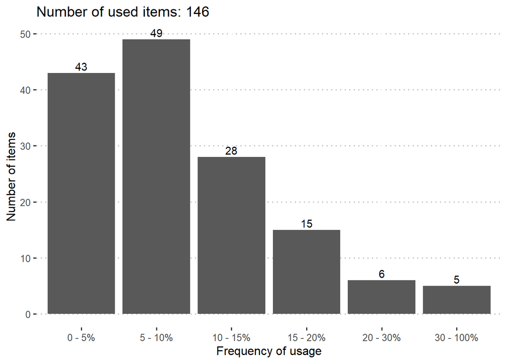

```r
#Prepare cuts
cuts <- cut(items_usage$freq, breaks = c(0, 0.05, 0.1, 0.15, 0.2, 0.3, 1), labels = c("0 - 5%", "5 - 10%", "10 - 15%", "15 - 20%", "20 - 30%", "30 - 100%"), dig.lab = 0)
df_freq <- as.data.frame(table(cuts))

#Plot distribution
ggplot(df_freq, aes(x = cuts, y = Freq)) +
  xlab("Frequency of usage") +
  ylab("Number of items") +
  geom_bar(stat = "identity") +
  geom_text(aes(label = Freq), vjust = -0.3) +
  ggtitle(paste0("Number of used items: ", length(which(items_usage$freq > 0)))) +
  theme_pubclean()
```

Parameters of used 146 items:

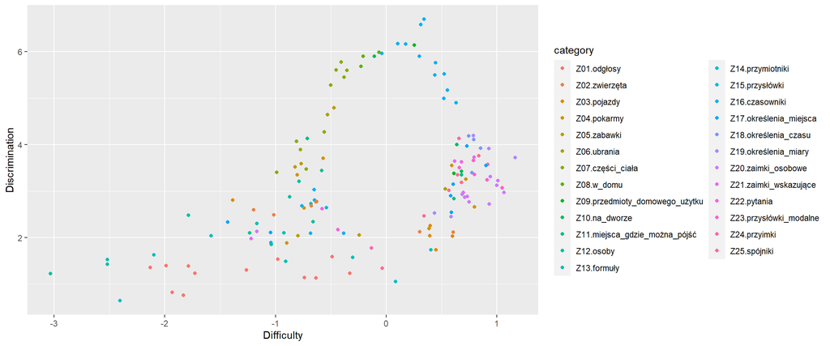

```r
best_items <- items_usage[1:length(which(items_usage$freq > 0)), ]

#Prepare df with only used items with IRT params
best_items_ids <- paste0("item", best_items$number.ws)
mirt_params_IRT <- as.data.frame(coef(mirt_model, simplify = TRUE, IRTpars = TRUE)$items)[1:2]
mirt_params_IRT_best <- mirt_params_IRT[best_items_ids, ]
mirt_params_IRT_best <- cbind(mirt_params_IRT_best, best_items)

#Create plot
ggplot(mirt_params_IRT_best, aes(b, a, colour = category)) +
  geom_point() +
  xlab("Difficulty") +
  ylab("Discrimination")
```

Parameters of used 146 w.r.t. all items:

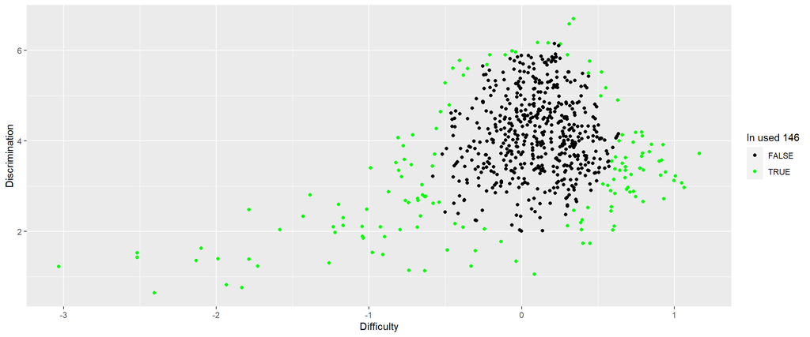

```r
#Prepare df with all params
mirt_params_IRT <- cbind(mirt_params_IRT, cdi)
mirt_params_IRT$top100 <- FALSE
mirt_params_IRT[best_items_ids, "top100"] <- TRUE

#Create plot
ggplot(mirt_params_IRT, aes(b, a, colour = top100)) +
  geom_point() +
  xlab("Difficulty") +
  ylab("Discrimination") +
  labs(colour = "In used 146") +
  scale_color_manual(values = c("Black", "Green"))
```

# Models with restricted set of items

Let’s create models with 146 items that was used during last simulations:

## mirt 61 quadratures

```r
responses_r <- responses[,best_items_ids]
```

```r
mirt_model <- mirt(responses_r, 1, SE=TRUE)
```

```r
mirt_model
```

```
##
## Call:
## mirt(data = responses_r, model = 1, SE = TRUE)
##
## Full-information item factor analysis with 1 factor(s).
## Converged within 1e-04 tolerance after 313 EM iterations.
## mirt version: 1.33.2
## M-step optimizer: BFGS
## EM acceleration: Ramsay
## Number of rectangular quadrature: 61
## Latent density type: Gaussian
##
## Information matrix estimated with method: Oakes
## Second-order test: model is a possible local maximum
## Condition number of information matrix =  333.051
##
## Log-likelihood = -106062.7
## Estimated parameters: 292
## AIC = 212709.5; AICc = 212794.9
## BIC = 214385.4; SABIC = 213457.7
## G2 (1e+10) = 177145.9, p = 1
## RMSEA = 0, CFI = NaN, TLI = NaN
```

```r
mirt_params <- as.data.frame(coef(mirt_model, simplify = TRUE)$items)[1:2]
head(mirt_params)
```

```
##               a1          d
## item457 5.396086  0.0194744
## item539 5.985552 -2.2752072
## item183 5.536202  2.1099753
## item521 5.140229 -2.9367872
## item188 5.305806  2.5300620
## item597 4.761982 -3.9527695
```

Let’s check if increasing number of quadratures changes something here:

## mirt 101 quadratures

```r
mirt_model <- mirt(responses_r, 1, SE=TRUE, quadpts = 101)
```

```r
mirt_model
```

```
##
## Call:
## mirt(data = responses_r, model = 1, SE = TRUE, quadpts = 101)
##
## Full-information item factor analysis with 1 factor(s).
## Converged within 1e-04 tolerance after 443 EM iterations.
## mirt version: 1.33.2
## M-step optimizer: BFGS
## EM acceleration: Ramsay
## Number of rectangular quadrature: 101
## Latent density type: Gaussian
##
## Information matrix estimated with method: Oakes
## Second-order test: model is a possible local maximum
## Condition number of information matrix =  410.2295
##
## Log-likelihood = -106054.3
## Estimated parameters: 292
## AIC = 212692.6; AICc = 212777.9
## BIC = 214368.5; SABIC = 213440.7
## G2 (1e+10) = 177128.9, p = 1
## RMSEA = 0, CFI = NaN, TLI = NaN
```

```r
mirt_params <- as.data.frame(coef(mirt_model, simplify = TRUE)$items)[1:2]
head(mirt_params)
```

```
##               a1          d
## item457 5.542044  0.2552413
## item539 6.125993 -2.0116799
## item183 5.689915  2.3519870
## item521 5.284045 -2.7206787
## item188 5.456489  2.7640357
## item597 4.894170 -3.7548215
```

So there’s gain in Log-likelihood and parameters are a bit different. Let’s check if there are any ceiling or floor items:

## mirt 61 quadratures no easy items

```r
difficulties <- colSums(responses_r) / nrow(responses_r)
```

```r
any(difficulties > 0.95)
```

```
## [1] TRUE
```

```r
which(difficulties > 0.95)
```

```
## item366 item349
##     111     122
```

```r
any(difficulties < 0.05)
```

```
## [1] FALSE
```

Let’s remove very easy items:

```r
responses_r <- responses[, best_items_ids[!best_items_ids %in% names(which(difficulties > 0.95))]]
ncol(responses_r)
```

```
## [1] 144
```

And again create model:

```r
mirt_model <- mirt(responses_r, 1, SE=TRUE)
```

```r
mirt_model
```

```
##
## Call:
## mirt(data = responses_r, model = 1, SE = TRUE)
##
## Full-information item factor analysis with 1 factor(s).
## Converged within 1e-04 tolerance after 301 EM iterations.
## mirt version: 1.33.2
## M-step optimizer: BFGS
## EM acceleration: Ramsay
## Number of rectangular quadrature: 61
## Latent density type: Gaussian
##
## Information matrix estimated with method: Oakes
## Second-order test: model is a possible local maximum
## Condition number of information matrix =  304.4737
##
## Log-likelihood = -105373.3
## Estimated parameters: 288
## AIC = 211322.6; AICc = 211405.5
## BIC = 212975.6; SABIC = 212060.6
## G2 (1e+10) = 175775.3, p = 1
## RMSEA = 0, CFI = NaN, TLI = NaN
```

```r
mirt_params <- as.data.frame(coef(mirt_model, simplify = TRUE)$items)[1:2]
head(mirt_params)
```

```
##               a1           d
## item457 5.396416  0.02092769
## item539 5.985496 -2.27406195
## item183 5.543720  2.11503320
## item521 5.139976 -2.93578025
## item188 5.303671  2.53209929
## item597 4.763347 -3.95303941
```

## mirt 101 quadratures no easy items

```r
mirt_model <- mirt(responses_r, 1, SE=TRUE, quadpts = 101)
```

```r
mirt_model
```

```
##
## Call:
## mirt(data = responses_r, model = 1, SE = TRUE, quadpts = 101)
##
## Full-information item factor analysis with 1 factor(s).
## Converged within 1e-04 tolerance after 472 EM iterations.
## mirt version: 1.33.2
## M-step optimizer: BFGS
## EM acceleration: Ramsay
## Number of rectangular quadrature: 101
## Latent density type: Gaussian
##
## Information matrix estimated with method: Oakes
## Second-order test: model is a possible local maximum
## Condition number of information matrix =  408.1521
##
## Log-likelihood = -105365.1
## Estimated parameters: 288
## AIC = 211306.2; AICc = 211389.1
## BIC = 212959.2; SABIC = 212044.1
## G2 (1e+10) = 175758.9, p = 1
## RMSEA = 0, CFI = NaN, TLI = NaN
```

```r
mirt_params <- as.data.frame(coef(mirt_model, simplify = TRUE)$items)[1:2]
head(mirt_params)
```

```
##               a1         d
## item457 5.542489  0.257072
## item539 6.126766 -2.010400
## item183 5.696225  2.357507
## item521 5.284046 -2.719469
## item188 5.453128  2.766220
## item597 4.896645 -3.755433
```

So still *model with higher number of quadratures gains Log-Likelihood even without these very easy items*. Let’s check if there is more precision to gain with higher number of quadratures:

## mirt 151 quadratures no easy items

```r
mirt_model <- mirt(responses_r, 1, SE=TRUE, quadpts = 151, technical=list(NCYCLES=3000))
```

```r
mirt_model
```

```
##
## Call:
## mirt(data = responses_r, model = 1, SE = TRUE, quadpts = 151,
##     technical = list(NCYCLES = 3000))
##
## Full-information item factor analysis with 1 factor(s).
## Converged within 1e-04 tolerance after 469 EM iterations.
## mirt version: 1.33.2
## M-step optimizer: BFGS
## EM acceleration: Ramsay
## Number of rectangular quadrature: 151
## Latent density type: Gaussian
##
## Information matrix estimated with method: Oakes
## Second-order test: model is a possible local maximum
## Condition number of information matrix =  396.1316
##
## Log-likelihood = -105365.1
## Estimated parameters: 288
## AIC = 211306.2; AICc = 211389.1
## BIC = 212959.1; SABIC = 212044.1
## G2 (1e+10) = 175758.8, p = 1
## RMSEA = 0, CFI = NaN, TLI = NaN
```

```r
mirt_params <- as.data.frame(coef(mirt_model, simplify = TRUE)$items)[1:2]
head(mirt_params)
```

```
##               a1          d
## item457 5.544804  0.2612432
## item539 6.129741 -2.0058072
## item183 5.698214  2.3616808
## item521 5.286116 -2.7152839
## item188 5.455419  2.7703726
## item597 4.899022 -3.7518429
```

No further improvement, yay! So *101 quadratures is optimal number here*. Let’s check ltm results:

## ltm 101 quadratures no easy items

```r
ltm_model <- ltm(responses_r ~ z1, IRT.param = FALSE, control = list(GHk = 101))
```

```r
summary(ltm_model)$logLik
```

```
## [1] -105508.1
```

```r
ltm_params <- as.data.frame(coef(ltm_model))
head(ltm_params)
```

```
##         (Intercept)       z1
## item457  -0.5350665 4.818365
## item539  -2.8019673 5.180037
## item183   1.5111702 4.942982
## item521  -3.4107188 4.504639
## item188   1.9632668 4.776074
## item597  -4.4195379 4.216368
```

## ltm 101 quadratures + 472 iterations no easy items

Number of iterations is analogous to what mirt had.

```r
ltm_model <- ltm(responses_r ~ z1, IRT.param = FALSE, control = list(iter.em = 472, GHk = 101))
```

```r
summary(ltm_model)$logLik
```

```
## [1] -105508.1
```

```r
ltm_params <- as.data.frame(coef(ltm_model))
head(ltm_params)
```

```
##         (Intercept)       z1
## item457  -0.5363577 4.821092
## item539  -2.8038344 5.180041
## item183   1.5102752 4.941906
## item521  -3.4139108 4.506383
## item188   1.9626013 4.774072
## item597  -4.4218721 4.216612
```

## TAM default

```r
tam_model <- tam.mml.2pl(responses_r, irtmodel="2PL")
```

```r
tam_model
```

```
## TAM 3.7-16 (2021-06-24 14:31:37)
##
## Call:
## tam.mml.2pl(resp = responses_r, irtmodel = "2PL")
##
## Multidimensional Item Response Model in TAM
##
## Deviance= 212688.7  | Log Likelihood= -106344.4
## Number of persons used= 2297
## Number of estimated parameters= 288
## AIC= 213265
## BIC= 214918
```

```r
tam_params<-data.frame(a1=tam_model$item[,"B.Cat1.Dim1"], d=tam_model$xsi$xsi)
head(tam_params)
```

```
##         a1          d
## 1 3.531167 -0.2420259
## 2 3.850963  1.8424596
## 3 3.681170 -2.2371657
## 4 3.296592  2.5104233
## 5 3.667770 -2.7144526
## 6 3.086721  3.5331538
```

# TAM 101 snodes

```r
tam_model <- tam.mml.2pl(responses_r, irtmodel="2PL", control=list(snodes = 101, QMC=FALSE))
```

```r
tam_model
```

```
## TAM 3.7-16 (2021-06-24 14:31:37)
##
## Call:
## tam.mml.2pl(resp = responses_r, irtmodel = "2PL", control = list(snodes = 101,
##     QMC = FALSE))
##
## Multidimensional Item Response Model in TAM
##
## Deviance= 210973.5  | Log Likelihood= -105486.7
## Number of persons used= 2297
## Number of estimated parameters= 288
## AIC= 211549
## BIC= 213202
```

```r
tam_params<-data.frame(a1=tam_model$item[,"B.Cat1.Dim1"], d=tam_model$xsi$xsi)
head(tam_params)
```

```
##         a1          d
## 1 6.264259  0.2338289
## 2 6.863393  2.5177418
## 3 6.402826 -1.8534249
## 4 5.922441  3.1649751
## 5 6.075674 -2.2662743
## 6 5.501751  4.1719524
```

# CTT difficulty and discrimination

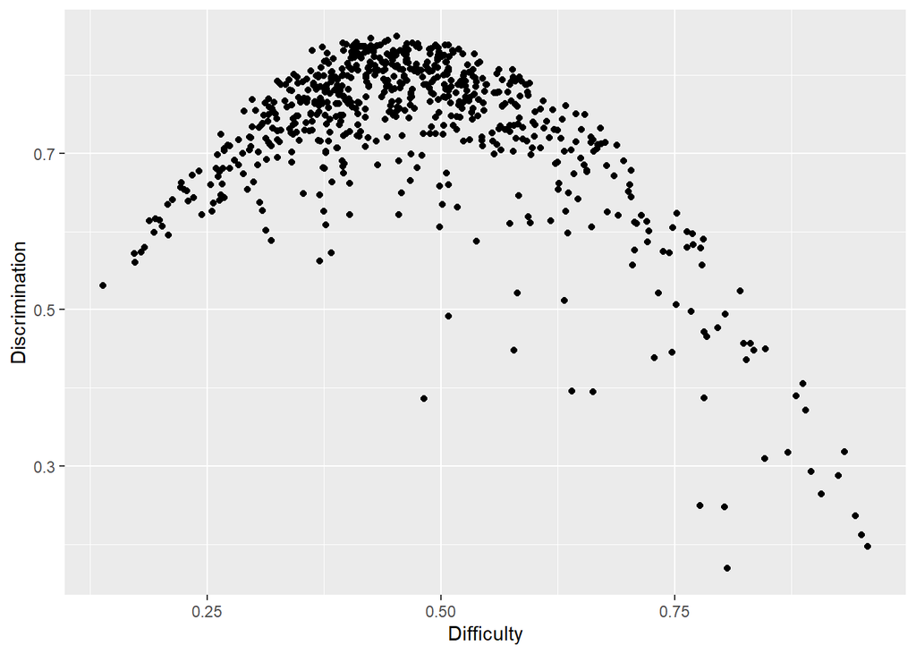

```r
difficulties <- colSums(responses) / nrow(responses)
discriminations <- c()
row_sums <- rowSums(responses)

for (item in colnames(responses)){
  item_responses <- responses[,item]
  cor <- cor(item_responses, row_sums)
  discriminations <- c(discriminations, cor)
}

ctt_params <- data.frame(Dffclt = difficulties, Dscrmn = discriminations)

ggplot(ctt_params, aes(Dffclt, Dscrmn)) +
  geom_point() +
  xlab("Difficulty") +
  ylab("Discrimination")
```